# APRESENTAÇÃO 2 DE SOBREVIVÊNCIA

ANTÔNIO VICTOR

# BANCO DE DADOS

```
## # A tibble: 1,000 × 9
##    idade sexo   trabalho moradia grana_poup grana_corr…¹ valor…² duracao para_…³
##    <dbl> <chr>     <dbl> <chr>        <dbl>        <dbl>   <dbl>   <dbl> <chr>
##  1    67 male          2 own             NA            0    1169       6 radio/…
##  2    22 female        2 own              0            1    5951      48 radio/…
##  3    49 male          1 own              0           NA    2096      12 educat…
##  4    45 male          2 free             0            0    7882      42 furnit…
##  5    53 male          2 free             0            0    4870      24 car
##  6    35 male          1 free            NA           NA    9055      36 educat…
##  7    53 male          2 own              3           NA    2835      24 furnit…
##  8    35 male          3 rent             0            1    6948      36 car
##  9    61 male          1 own              2           NA    3059      12 radio/…
## 10    28 male          3 own              0            1    5234      30 car
## # … with 990 more rows, and abbreviated variable names ¹grana_corrent,
## #   ²valor_cred, ³para_que
```

#### O BANCO DE DADOS TEM COMO INTUIÇÃO A ANÁLISE DE TEMPO PARA QUE O EMPRESTIMO SEJA COMPLETAMENTE PAGO.

#### ENTRE AS VARIÁVEIS QUE SERÃO ANALISADAS, TEMOS:

- IDADE
- SEXO
- Trabalho (0 - não qualificado e não residente, 1 - não qualificado e residente, 2 - qualificado, 3 - altamente qualificado)
- Moradia (própria, alugada ou gratuita)
- QUANTIDADE DE DINHEIRO GUARDADA NA POUPANÇA (0- pouco, 1 - moderado, 2- rico, 3- bastante rico)
- QUANTIDADE DE DINHEIRO GUARDADA NA CONTA CORRENTE (0- pouco, 1 - moderado, 2- rico, 3- bastante rico)
- VALOR DO CRÉDITO QUE LHE FOI DADO ( MOEDA ALEMÃ)
- DURAÇÃO PARA QUE PAGUE O QUE É DEVIDO (MÊS)
- PARA QUE PEGOU EMPRESTADO ( rádio/TV, móveis/equipamentos, eletrodomésticos, consertos, férias/outros, educação, carro, negócios)

# DADOS FALTANTES

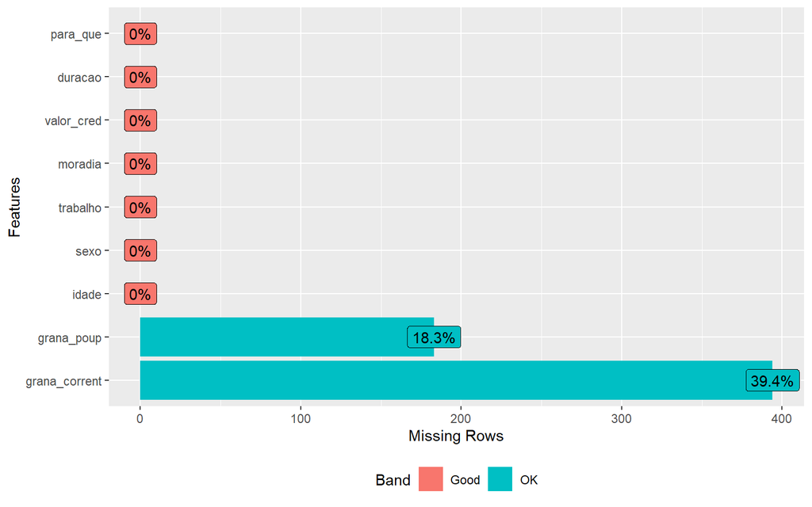

#### OBSERVE QUE CONTÊM DADOS FALTANTES NAS VARIÁVEIS GRANA_POUP E GRANA_CORRENT, LOGO TERÁ QUE SER FEITO ALGO A RESPEITO.

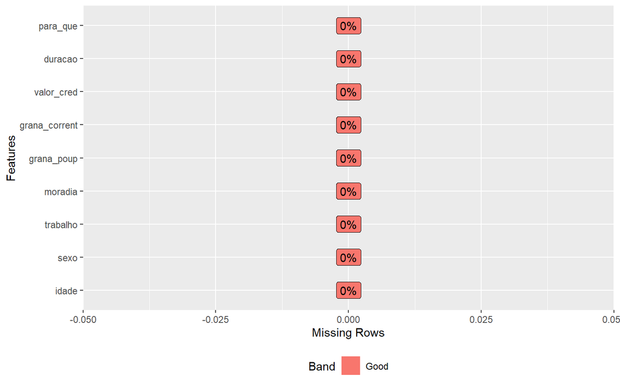

#### SE UTILIZANDO DA MODA, FOI RECUPERADO INFORMAÇÕES VALIOSAS DO BANCO DE DADOS, ASSIM PODE SE PROSSEGUIR COM A ANÁLISE.

# ANÁLISE DE SOBREVIVÊNCIA

### A análise da idade do indíviduo, houve um impasse, pois são muitas variáveis, assim, foi preciso agrupa-lás para poder prosseguir:

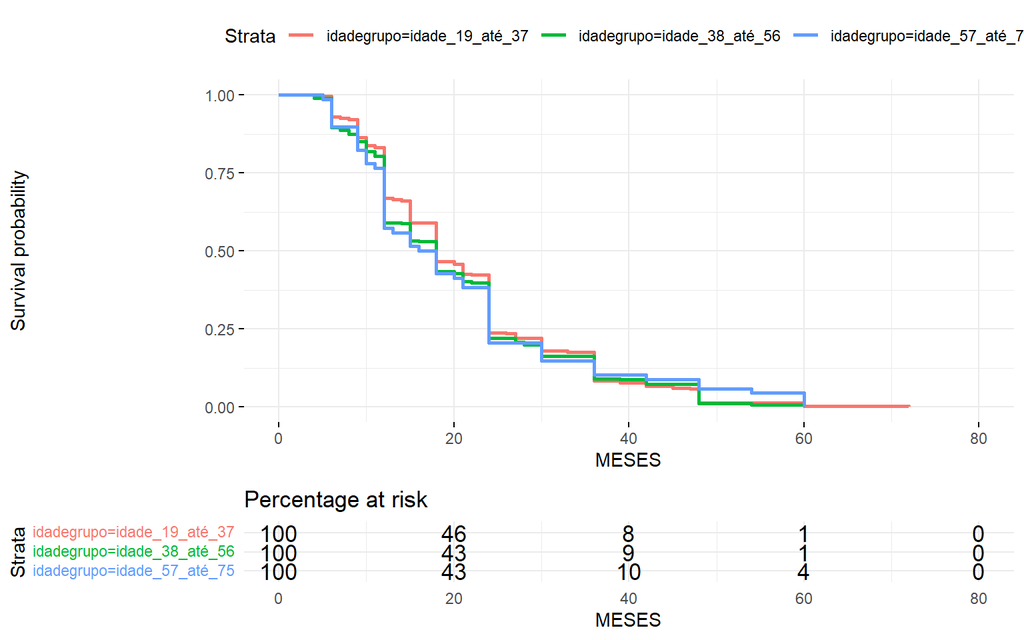

### OBSERVE QUE AS VARIÁVEIS NÃO ESTÃO BEM BALANCEADAS:

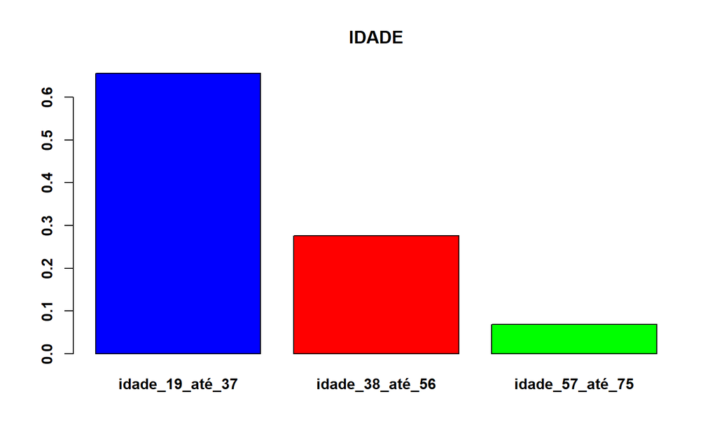

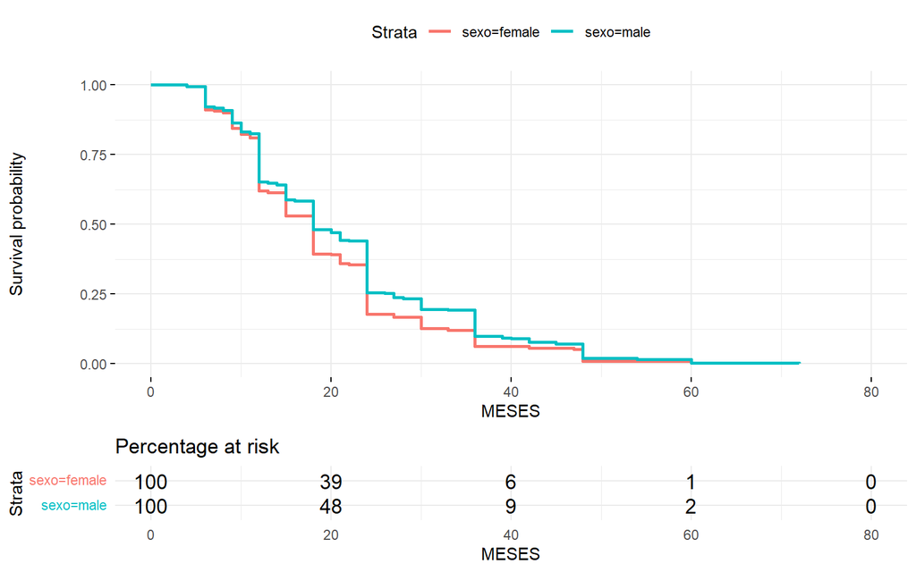

### OBSERVE QUE AS VARIÁVEIS NÃO ESTÃO BEM BALANCEADAS:

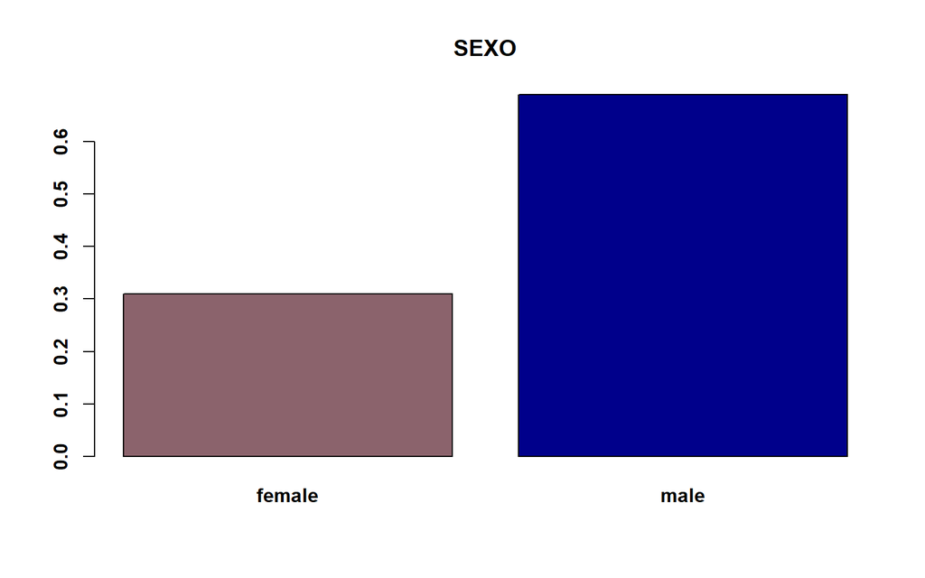

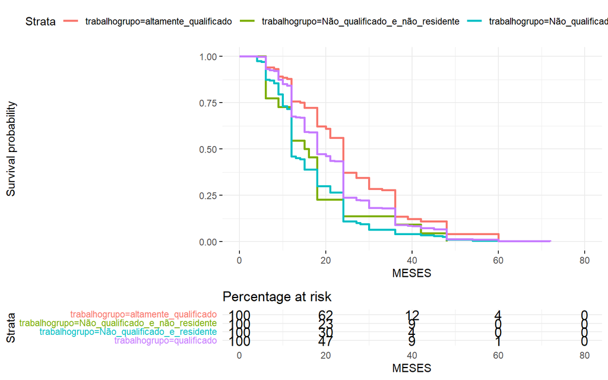

### OBSERVE QUE AS VARIÁVEIS NÃO ESTÃO BEM BALANCEADAS:

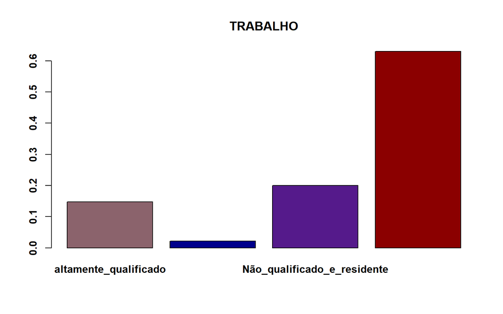

### INDIVIDUOS QUE MORAM COM OUTROS / NÃO ALUGA OU NÃO TEM CASA PRÓPRIA, TENDEM A DEMORAREM MAIS:

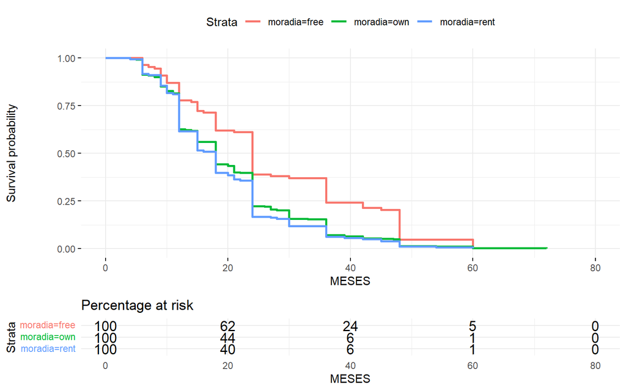

### OBSERVE QUE AS VARIÁVEIS NÃO ESTÃO BEM BALANCEADAS:

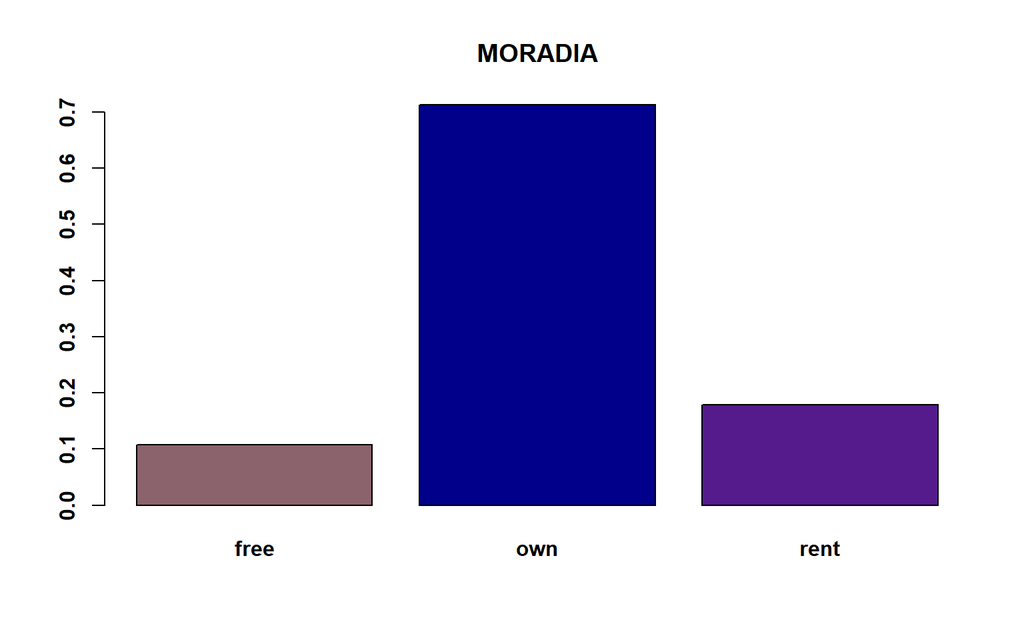

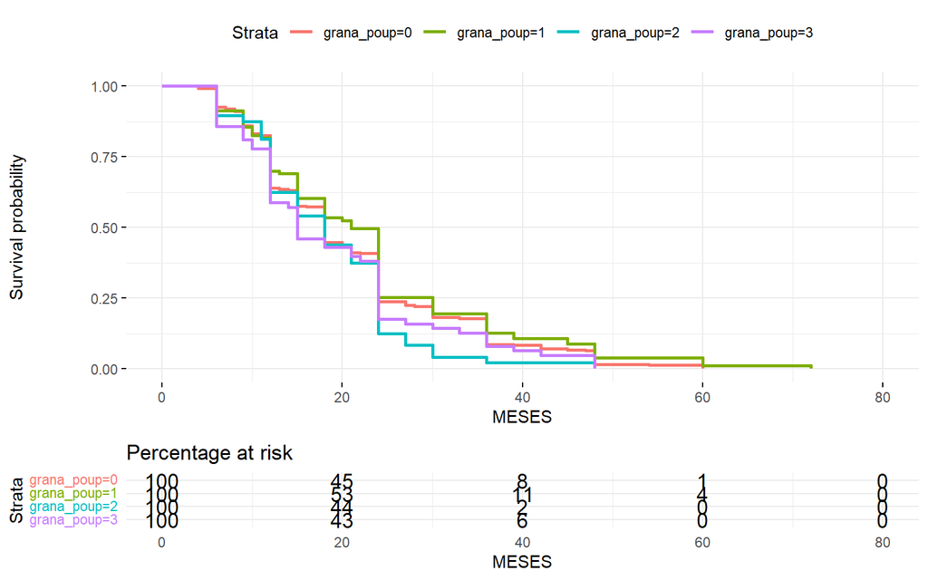

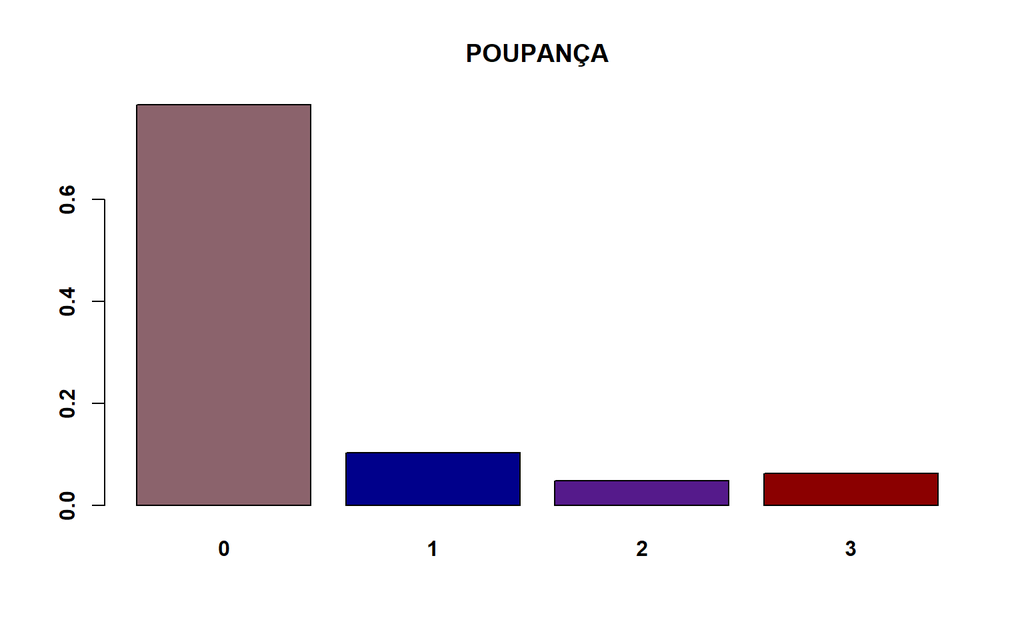

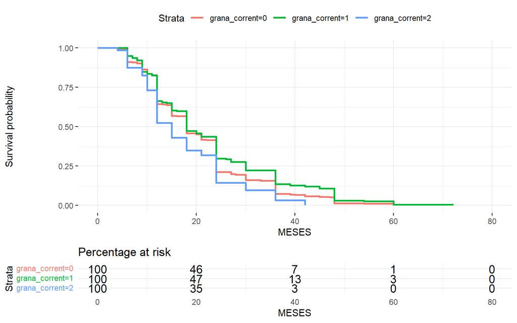

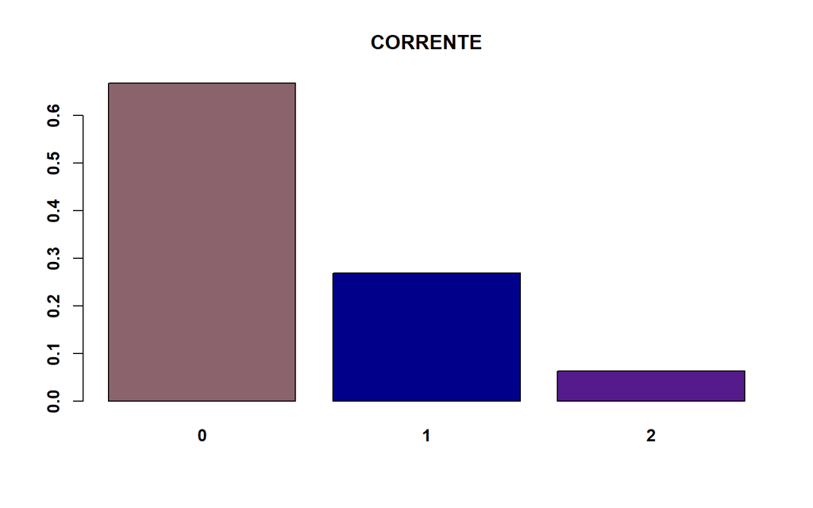

### A VARIÁVEL DE VALOR EMPRESTADO, DEVERÁ SER ANALISADA EM GRUPOS:

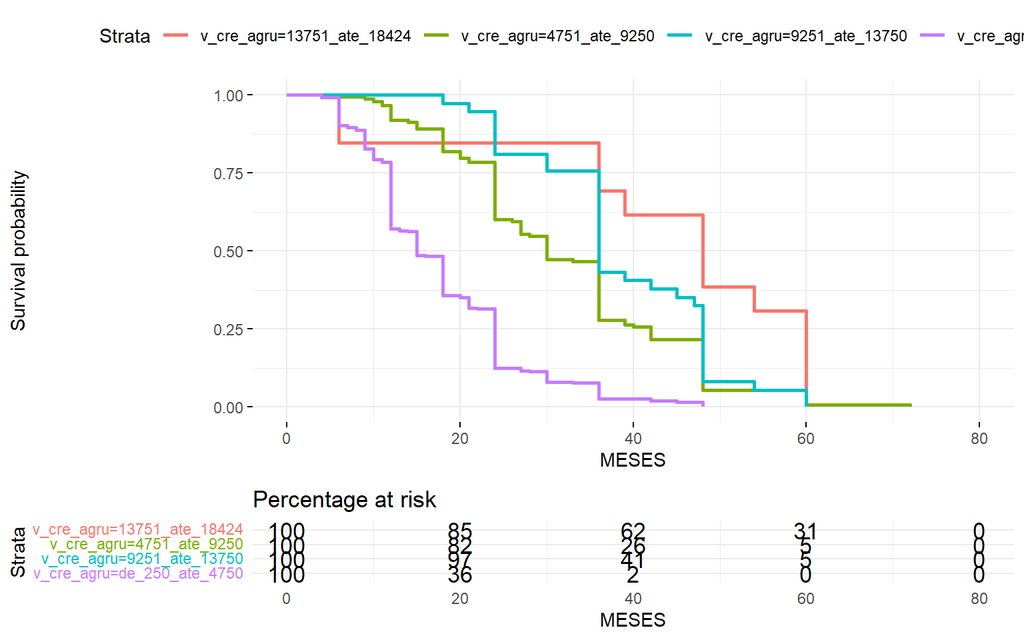

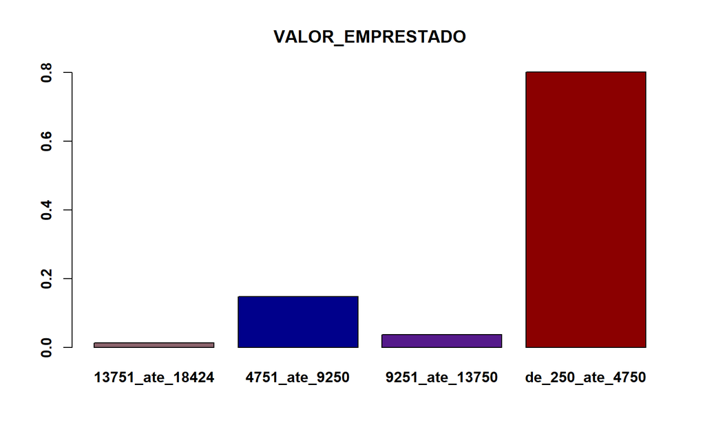

```
## Call: survfit(formula = Surv(dados$duracao) ~ para_que, data = dados)
##
##                 para_que=business
##  time n.risk n.event survival std.err lower 95% CI upper 95% CI
##     5     97       1   0.9897  0.0103      0.96979       1.0000
##     6     96       2   0.9691  0.0176      0.93523       1.0000
##     8     94       1   0.9588  0.0202      0.92000       0.9992
##     9     93       2   0.9381  0.0245      0.89141       0.9873
##    11     91       1   0.9278  0.0263      0.87774       0.9808
##    12     90       9   0.8351  0.0377      0.76437       0.9123
##    13     81       1   0.8247  0.0386      0.75245       0.9040
##    14     80       1   0.8144  0.0395      0.74063       0.8956
##    15     79       3   0.7835  0.0418      0.70569       0.8699
##    18     76      12   0.6598  0.0481      0.57194       0.7611
##    21     64       5   0.6082  0.0496      0.51847       0.7136
```

[output cut: 139 more lines]

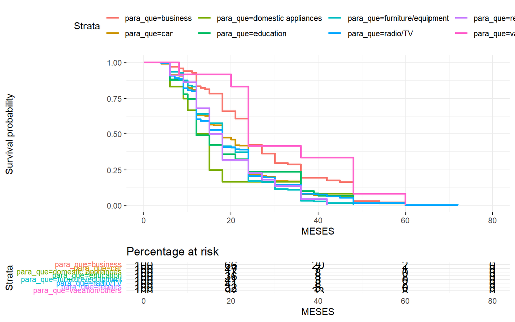

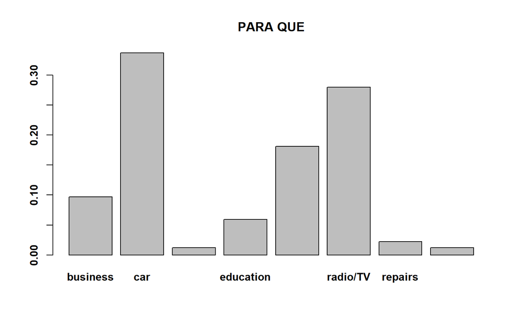

# TESTE DE PETO

```
## Call:
## survdiff(formula = Surv(dados$duracao) ~ idadegrupo, rho = 1)
##
##                              N Observed Expected (O-E)^2/E (O-E)^2/V
## idadegrupo=idade_19_até_37 656    354.9    369.2     0.556     2.814
## idadegrupo=idade_38_até_56 276    157.7    147.6     0.703     1.607
## idadegrupo=idade_57_até_75  68     39.4     35.3     0.487     0.868
##
##  Chisq= 2.9  on 2 degrees of freedom, p= 0.2
```

```
## Call:
## survdiff(formula = Surv(dados$duracao) ~ dados$sexo, rho = 1)
##
##                     N Observed Expected (O-E)^2/E (O-E)^2/V
## dados$sexo=female 310      181      162      2.31      5.41
## dados$sexo=male   690      371      390      0.96      5.41
##
##  Chisq= 5.4  on 1 degrees of freedom, p= 0.02
```

```
## Call:
## survdiff(formula = Surv(dados$duracao) ~ dados$trabalho, rho = 1)
##
##                    N Observed Expected (O-E)^2/E (O-E)^2/V
## dados$trabalho=0  22     14.3     9.95      1.93      3.12
## dados$trabalho=1 200    133.1    87.99     23.15     43.74
## dados$trabalho=2 630    337.9   358.45      1.18      5.60
## dados$trabalho=3 148     66.7    95.65      8.79     18.74
##
##  Chisq= 57.1  on 3 degrees of freedom, p= 2e-12
```

```
## Call:
## survdiff(formula = Surv(dados$duracao) ~ dados$moradia, rho = 1)
##
##                      N Observed Expected (O-E)^2/E (O-E)^2/V
## dados$moradia=free 108     45.8     72.7     9.960     20.83
## dados$moradia=own  713    401.1    386.3     0.564      3.19
## dados$moradia=rent 179    105.2     93.0     1.584      3.12
##
##  Chisq= 21.8  on 2 degrees of freedom, p= 2e-05
```

```
## Call:
## survdiff(formula = Surv(dados$duracao) ~ dados$grana_poup, rho = 1)
##
##                      N Observed Expected (O-E)^2/E (O-E)^2/V
## dados$grana_poup=0 786    432.7    434.9    0.0112    0.0882
## dados$grana_poup=1 103     53.2     60.2    0.8108    1.5665
## dados$grana_poup=2  48     28.5     24.9    0.5323    0.8984
## dados$grana_poup=3  63     37.6     32.0    0.9611    1.6793
##
##  Chisq= 3.9  on 3 degrees of freedom, p= 0.3
```

```
## Call:
## survdiff(formula = Surv(dados$duracao) ~ dados$grana_corrent,
##     rho = 1)
##
##                         N Observed Expected (O-E)^2/E (O-E)^2/V
## dados$grana_corrent=0 668      372    367.7    0.0561     0.283
## dados$grana_corrent=1 269      140    154.7    1.4395     3.404
## dados$grana_corrent=2  63       40     29.6    3.6354     6.143
##
##  Chisq= 8.4  on 2 degrees of freedom, p= 0.02
```

```
## Call:
## survdiff(formula = Surv(dados$duracao) ~ v_cre_agru, rho = 1)
##
##                              N Observed Expected (O-E)^2/E (O-E)^2/V
## v_cre_agru=13751_ate_18424  13     2.68     10.8      6.15      13.4
## v_cre_agru=4751_ate_9250   148    43.83    116.3     45.11     107.0
## v_cre_agru=9251_ate_13750   37     6.47     33.1     21.47      46.2
## v_cre_agru=de_250_ate_4750 802   499.07    391.8     29.36     190.9
##
##  Chisq= 194  on 3 degrees of freedom, p= <2e-16
```

```
## Call:
## survdiff(formula = Surv(dados$duracao) ~ dados$para_que, rho = 1)
##
##                                      N Observed Expected (O-E)^2/E (O-E)^2/V
## dados$para_que=business             97    39.04    66.60  11.40537   23.2604
## dados$para_que=car                 337   186.53   185.24   0.00907    0.0229
## dados$para_que=domestic appliances  12     8.09     4.93   2.02081    3.1543
## dados$para_que=education            59    35.90    29.18   1.54820    2.7096
## dados$para_que=furniture/equipment 181   104.23    97.11   0.52262    1.0410
## dados$para_que=radio/TV            280   161.78   148.07   1.26885    2.8918
## dados$para_que=repairs              22    12.66    11.56   0.10564    0.1739
## dados$para_que=vacation/others      12     3.81     9.36   3.28898    6.4652
##
##  Chisq= 35.9  on 7 degrees of freedom, p= 7e-06
```

## H0: DIFERENÇA NÃO É SIGNIFICATIVA (p>0.05)

## H1: DIFERENÇA É SIGNIFICATIVA (p≤0.05)

# DISTRIBUIÇÃO

### A DISTRIBUIÇÃO DE LOGNORMAL SE AJUSTOU MELHOR.

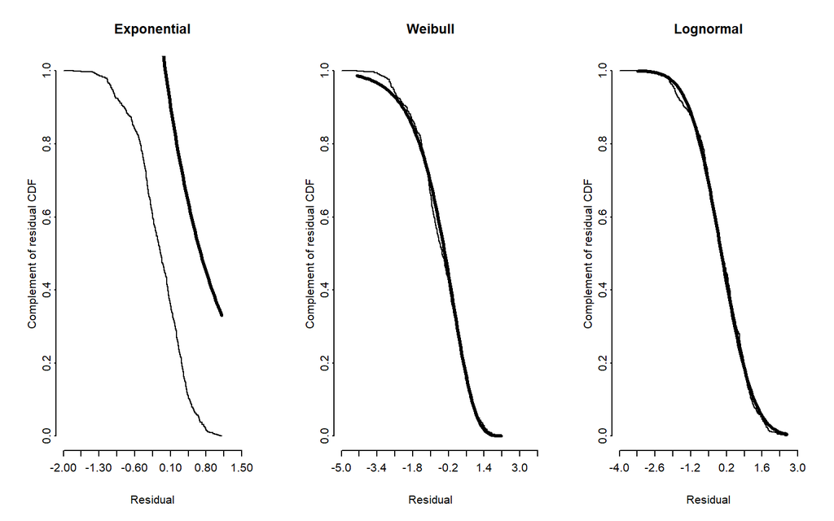

### NOS RESÍDUOS SE NOTA QUE NO LOGNORMAL TEM PONTOS MAIS INFLUENTES, POIS PASSA DO -3, SENDO QUE É MAIS ACEITO -3 À 3, E PARA ESTATÍSTICOS MUITO EXIGENTES, -2 À 2.

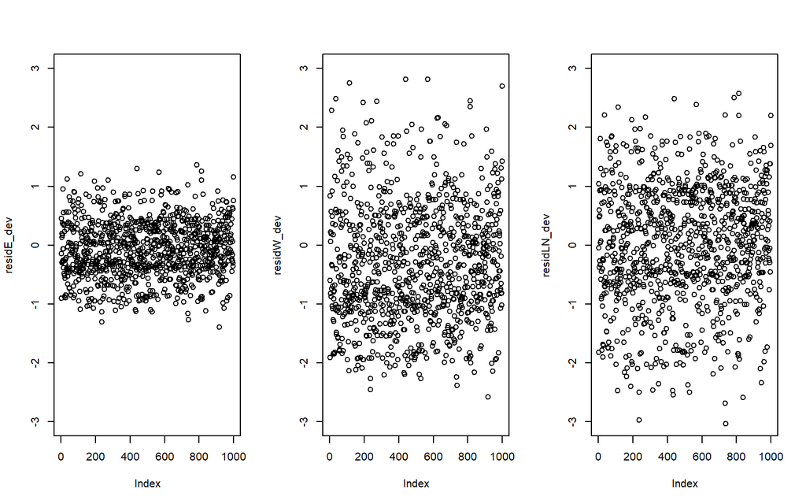

### NO PONTO INFLUENTE SOBRE VALOR PREDITO, SE NOTA QUE LOGNORMAL É O QUE MAIS TEM.

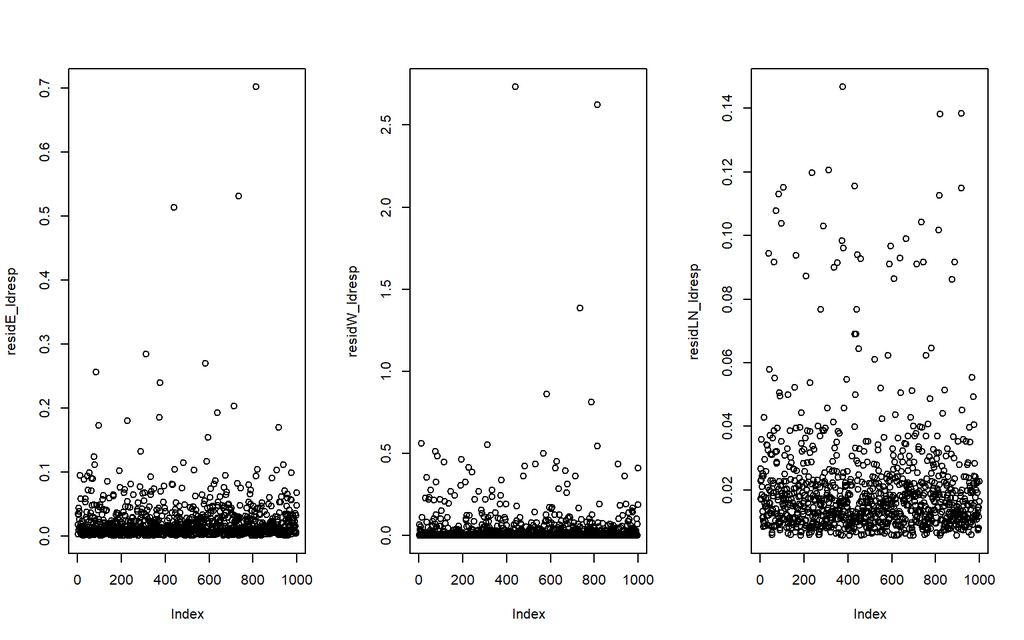

### NO PONTO INFLUENTE SOBRE VALOR O PARÂMETRO, SE NOTA QUE LOGNORMAL É O QUE MAIS TEM.

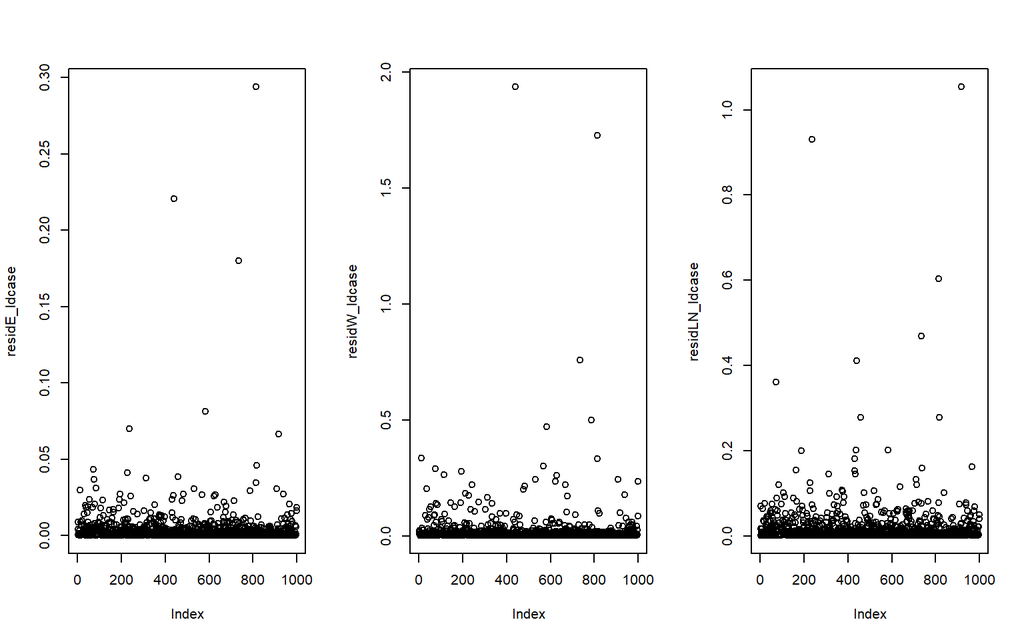

### PERANTE TUDO, SE MUDA A CONCLUSÃO QUE LOGNORMAL É O MAIS AJUSTADO, PARA, WEIBULL É O MAIS AJUSTADO!

# COX

### SE ATENTE A VARIÁVEL EXP(COEF), ELA SIGNIFICA QUANTO DE RISCO TEM CADA VARIÁVEL, SENDO O MENOR RISCO ESPERADO A VARIÁVEL TRABALHO, QUE DEU 0.85, SIGNIFICA QUE TEM 0.85X DE CHANCE.

```
## Call:
## coxph(formula = Surv(dados$duracao) ~ idadegrupo + sexo + trabalho +
##     moradia + grana_poup + grana_corrent + v_cre_agru + para_que,
##     data = dados)
##
##   n= 1000, number of events= 1000
##
##                                  coef exp(coef)  se(coef)      z Pr(>|z|)
## idadegrupoidade_38_até_56    0.169324  1.184504  0.075132  2.254 0.024216 *
## idadegrupoidade_57_até_75    0.184558  1.202687  0.134354  1.374 0.169546
## sexomale                    -0.113222  0.892952  0.073535 -1.540 0.123633
## trabalho                    -0.153514  0.857688  0.053352 -2.877 0.004010 **
## moradiaown                   0.399759  1.491465  0.112392  3.557 0.000375 ***
## moradiarent                  0.516479  1.676116  0.135516  3.811 0.000138 ***
## grana_poup                   0.001408  1.001409  0.038428  0.037 0.970769
## grana_corrent                0.029026  1.029451  0.055027  0.527 0.597855
## v_cre_agru4751_ate_9250      0.619710  1.858390  0.306330  2.023 0.043071 *
## v_cre_agru9251_ate_13750     0.289820  1.336187  0.340378  0.851 0.394511
## v_cre_agrude_250_ate_4750    1.761660  5.822092  0.307658  5.726 1.03e-08 ***
## para_quecar                  0.561239  1.752844  0.118072  4.753 2.00e-06 ***
## para_quedomestic appliances  0.139581  1.149792  0.310570  0.449 0.653118
## para_queeducation            0.681716  1.977267  0.169632  4.019 5.85e-05 ***
## para_quefurniture/equipment  0.468271  1.597230  0.129291  3.622 0.000293 ***
## para_queradio/TV             0.303334  1.354367  0.119681  2.535 0.011260 *
## para_querepairs              0.326670  1.386343  0.243016  1.344 0.178873
## para_quevacation/others      0.411790  1.509518  0.318260  1.294 0.195707
## ---
## Signif. codes:  0 '***' 0.001 '**' 0.01 '*' 0.05 '.' 0.1 ' ' 1
##
##                             exp(coef) exp(-coef) lower .95 upper .95
## idadegrupoidade_38_até_56      1.1845     0.8442    1.0223    1.3724
## idadegrupoidade_57_até_75      1.2027     0.8315    0.9243    1.5650
## sexomale                       0.8930     1.1199    0.7731    1.0314
## trabalho                       0.8577     1.1659    0.7725    0.9522
## moradiaown                     1.4915     0.6705    1.1966    1.8590
## moradiarent                    1.6761     0.5966    1.2851    2.1860
## grana_poup                     1.0014     0.9986    0.9288    1.0797
## grana_corrent                  1.0295     0.9714    0.9242    1.1467
## v_cre_agru4751_ate_9250        1.8584     0.5381    1.0195    3.3875
## v_cre_agru9251_ate_13750       1.3362     0.7484    0.6857    2.6037
## v_cre_agrude_250_ate_4750      5.8221     0.1718    3.1857   10.6404
## para_quecar                    1.7528     0.5705    1.3907    2.2093
## para_quedomestic appliances    1.1498     0.8697    0.6255    2.1134
## para_queeducation              1.9773     0.5057    1.4180    2.7571
## para_quefurniture/equipment    1.5972     0.6261    1.2397    2.0579
## para_queradio/TV               1.3544     0.7384    1.0712    1.7124
## para_querepairs                1.3863     0.7213    0.8610    2.2322
## para_quevacation/others        1.5095     0.6625    0.8090    2.8167
##
## Concordance= 0.674  (se = 0.011 )
## Likelihood ratio test= 322.7  on 18 df,   p=<2e-16
## Wald test            = 265.6  on 18 df,   p=<2e-16
## Score (logrank) test = 287.8  on 18 df,   p=<2e-16
```

### PELO TESTE, TEM QUAIS SÃO AS SIGNIFICATIVAS:

### H0: NÃO É SIGNIFICATIVA (p>0.05)

### H1: É SIGNIFICATIVA (p≤0.05)

```
##                 chisq df       p
## idadegrupo     4.3140  2 0.11567
## sexo           1.2117  1 0.27100
## trabalho      11.5718  1 0.00067
## moradia        2.0614  2 0.35675
## grana_poup     0.0687  1 0.79325
## grana_corrent  1.7544  1 0.18532
## v_cre_agru    22.5369  3 5.0e-05
## para_que      24.4977  7 0.00093
## GLOBAL        57.8743 18 4.5e-06
```

### PARA OBSERVAR SE ESTÃO BEM DISTRIBUÍDOS, É PARECIDO COM O GRÁFICO DE ENVELOPE

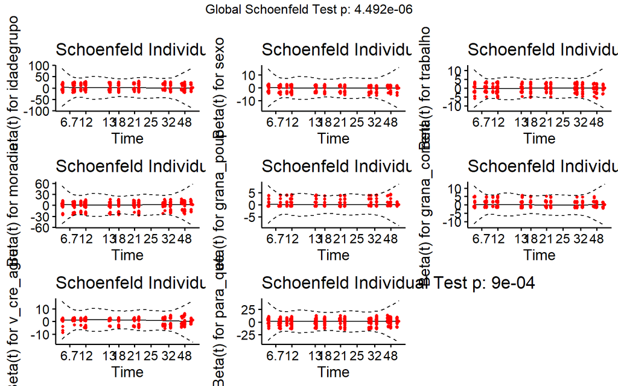

### PARA OBSERVAR SE OS RESÍDUOS ESTÃO BEM DISTRIBUÍDOS, SENDO A PERFEIÇÃO A LINHA EM VERMELHO.

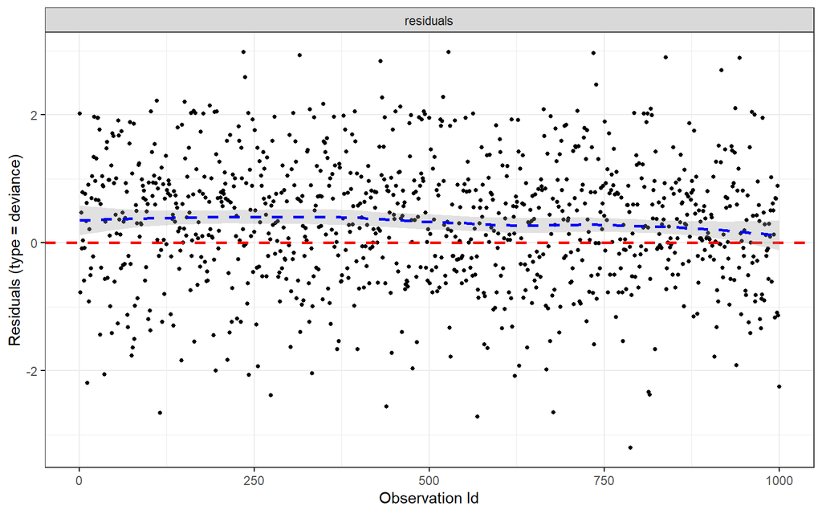